# Wine reviews

mdneuzerling

08 January, 2018

## Incomplete data

From the data viusalisation below, we can see that the price data for the wine is incomplete. Approximately 7% of the price values are missing. The other missing values are actually empty strings. Interestingly, a data frame doesn’t treat these as missing by default, but a tibble does.

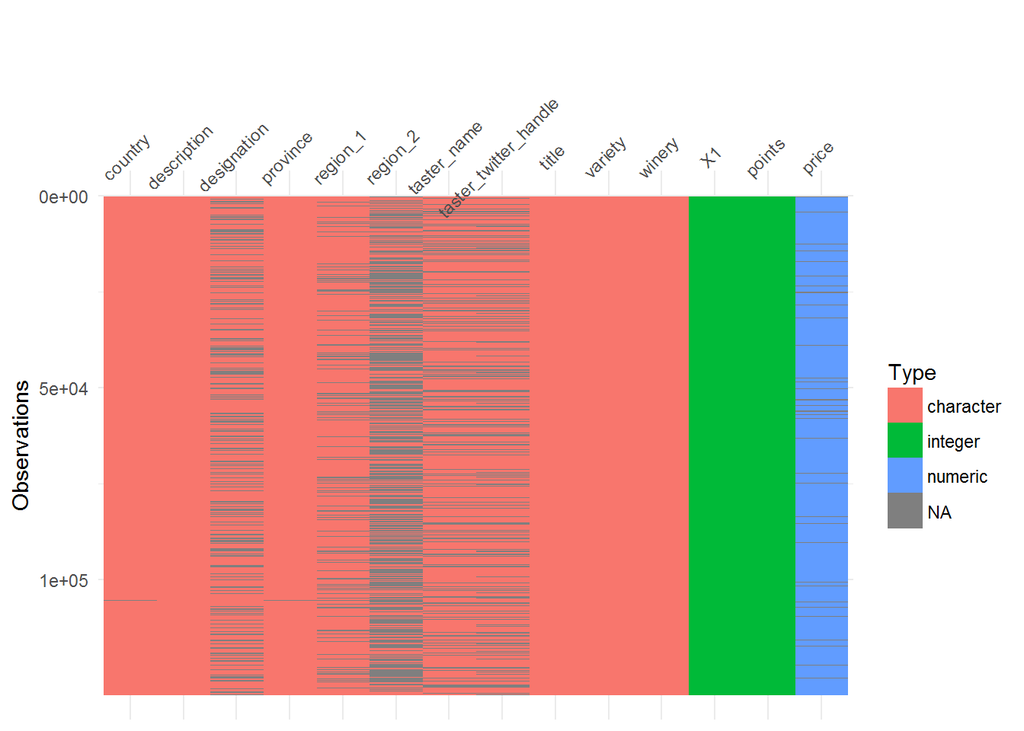

```r
wine %>% vis_dat(warn_large_data = FALSE)
```

## Text analysis

Each wine is accompanied by a single-paragraph review. Using the tidytext package we can investigate word and n-gram frequency of these reviews. We first break down the review into single words.

```r
wine_words <- wine %>%
    unnest_tokens(word, description) %>%
    anti_join(stop_words, by = "word") %>%
    filter(word != "wine")
```

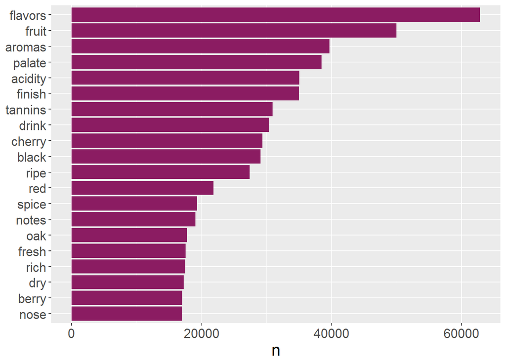

```r
wine_words %>%
    count(word, sort = TRUE) %>%
    head(20) %>%
    mutate(word = reorder(word, n)) %>%
    ggplot(aes(word, n)) +
    geom_col(fill = "maroon4") +
    xlab(NULL) +
    theme(text = element_text(size=16)) +
    coord_flip()
```

I’m not sure what purpose word clouds serve, but they seem mandatory at this point.

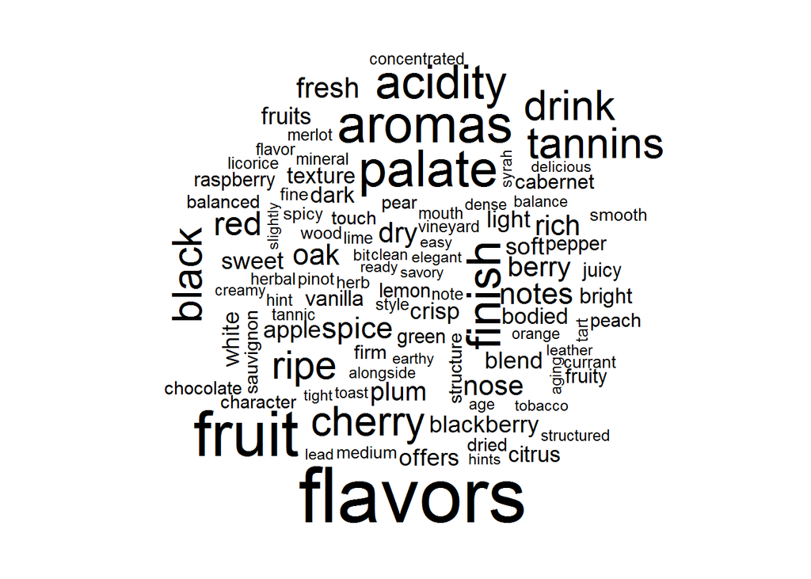

```r
wine_words %>%
  count(word) %>%
  with(wordcloud(word, n, max.words = 100))
```

An n-gram is a tuple of words appearing sequentially in order within an utterance. For example, in the utterance “My name is Fred”, “is Fred” is a 2-gram and “name is Fred” is a 3-gram. A word could also be considered as a 1-gram. Below we define the 2-grams (bigrams) and 3-grams (trigrams) of the wine descriptions.

Along with the `ngram` column, the `separate` column provides us with separate columns for each word in the n-gram. The column names for these words are dynamically generated in the `wine_ngrams` helper function, which provides outputs a tibble of n-grams for a given n. We then use these new word columns to filter out the stop words, although this time we include n-grams with the word “wine”.

```r
wine_ngrams <- function(n) {
    wine %>%
        unnest_tokens(ngram, description, token = "ngrams", n = n) %>%
        separate(
            ngram,
            sapply(1:n, function(x) {paste0("word", x)}), # eg, "word1", "word2"
            sep = " ",
            remove = FALSE # keep the n-gram in the tibble
        )
}

wine_2grams <- wine_ngrams(2) %>%
    filter(!word1 %in% stop_words$word) %>%
    filter(!word2 %in% stop_words$word)
wine_3grams <- wine_ngrams(3) %>%
    filter(!word1 %in% stop_words$word) %>%
    filter(!word2 %in% stop_words$word) %>%
    filter(!word3 %in% stop_words$word)
```

There are 1436412 2-grams, taking up around 201 megabytes of memory, and 649539 3-grams, taking up around 122 megabytes. The drop in number and size is due to the filtering of the stop words.

We can also plot the frequency of the 2- and 3-grams:

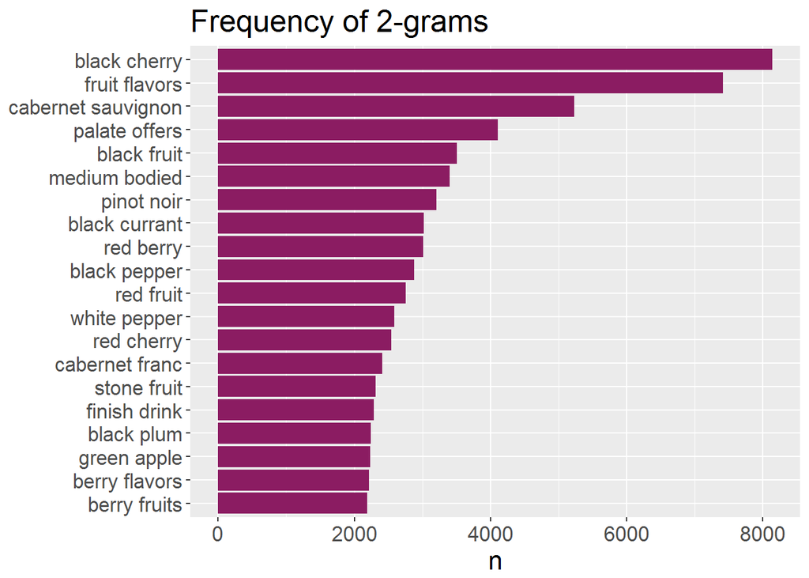

```r
plot_ngram_frequency <- function(x) {
    get(paste0("wine_", x, "grams")) %>%
        count(ngram, sort = TRUE) %>%
        head(20) %>%
        mutate(ngram = reorder(ngram, n)) %>%
        ggplot(aes(ngram, n)) +
        geom_col(fill = "maroon4") +
        xlab(NULL) +
        theme(text = element_text(size=16)) +
        coord_flip() +
        ggtitle(paste0("Frequency of ", x, "-grams"))
}

plot_ngram_frequency(2)
```

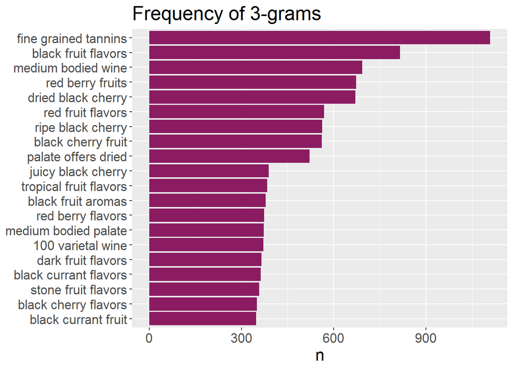

```r
plot_ngram_frequency(3)
```